# Swiftkey Data Exploration

Enrique Pérez Herrero

March 19, 2016

## Coursera Data Science Specialization Capstone: Milestone Report

## 0. EXECUTIVE SUMMARY.

This report is a milestone in the *Data Science Specialization Capstone* from *Coursera* by *Johns Hopkins University*.

The data is from a corpus called HC Corpora (www.corpora.heliohost.org). See the readme file at http://www.corpora.heliohost.org/aboutcorpus.html for details on the corpora available. The data came from a series of text documents in severallanguages from blogs, news and twitter content and came from [Swiftkey](https://swiftkey.com). This report uses Natural Language Processing (NLP) techniques to explore the data sets, the code includes several functions to easily expand the exploration to other languages or other data sets. This milestone is intended to be used to create a interactive app using [Shiny](http://shiny.rstudio.com/) package.

### 0.1 Key Findings

- Date set is huge and it must be sample and preprocess to be handle by an online app
- `textcat` package gives poor results when identifying foreign words.
- More frequent n-grams are found.

### 0.2 Plan for creating a prediction algorithm and Shiny app

- The app must be online and the n-grams probabilities must be obtained previously
- Functions for plotting as a wordcloud or barplots can be reused in the app.

## 1. CLEANING ENVIRONMENT AND LOADING PACKAGES

```r
rm(list = ls(all = TRUE))
gc(reset = TRUE)

library(tm)
library(readr)
library(wordcloud)
library(RWeka)
library(stringi)
library(reshape2)
library(ggplot2)
library(RColorBrewer)
library(knitr)
library(textcat)
library(dplyr)
```

#### 1.1 LOADING DATA ACCESS FUNCTIONS

The source code for data access functions can be downloaded from [Github](https://github.com/EnriquePH/NLP-Coursera-Swiftkey/blob/master/Swiftkey_Data_Access_Functions.R) and the zip file with the data from: Captone Dataset

```r
source("Swiftkey_Data_Access_Functions.R")
```

#### 1.2 PARAMETERS

```r
AVAILABLE_LANGUAGES
```

```
## english russian  german finnish
## "en_US" "ru_RU" "de_DE" "fi_FI"
```

```r
LANGUAGE <- AVAILABLE_LANGUAGES[1]
SAMPLE_SIZE <- 1000
```

The selected languaje in this report is english

#### 1.3 LIST DATA FILES

```r
files_list <- get_files_path(LANGUAGE)
names(files_list) <- list.files(get_path(LANGUAGE), pattern = "*.txt")
```

### 2. FILES SUMMARY

```r
Mb <- 2**20 # One Megabyte
# Files names
files_name <- as.vector(names(files_list))

# Files sizes
files_size <- round(file.info(files_list)$size / Mb)

# Number of lines
files_lines <- sapply(files_list,
                      function(x) length(readLines(x, warn = FALSE)))

# Counting words
files_stats <- sapply(files_list,
               function(x) stri_stats_latex(readLines(x, warn = FALSE)))

# Creating data frame.
files_words <- data.frame(t(files_stats))$Words
files_summary_df <- data.frame(row.names = files_name,
                               files_size,
                               files_lines,
                               files_words)
files_summary_df <- t(files_summary_df)
```

```r
print(files_summary_df)
```

```
##             en_US.blogs.txt en_US.news.txt en_US.twitter.txt
## files_size              200            196               159
## files_lines          899288          77259           2360148
## files_words        37865888        2665742          30578891
```

### 3. SAMPLE TEXT FILES

The original files are sampled by line to a total of 1000 lines per file.

```r
set.seed(pi)
sapply(get_files_path(LANGUAGE),
       function(x) sample_text_file(x, size = SAMPLE_SIZE)
       )

# Directory for sample files.
sample_dir(LANGUAGE)
```

### 4. CREATE SAMPLE FILES CORPUS

```r
crps <- Corpus(DirSource(sample_dir(LANGUAGE), encoding = "UTF-8"),
              readerControl = list(language = LANGUAGE))
```

### 5. CORPUS TRANSFORMATIONS

The transformations does not include filtering by stopwords because it is nedeed a complete set of n-grams.

```r
corpus_cleaning <- function(my_corpus){
  my_corpus <- tm_map(my_corpus, stripWhitespace)
  my_corpus <- tm_map(my_corpus, removePunctuation)
  my_corpus <- tm_map(my_corpus, content_transformer(tolower))
  my_corpus <- tm_map(my_corpus, removeNumbers)
  return(my_corpus)
}

crps <- corpus_cleaning(crps)
```

### 6. DISTRIBUTION OF WORD FREQUENCIES

```r
Tokenizer <- function(x, n_gram = 1){
  NGramTokenizer(x, Weka_control(min = n_gram, max = n_gram))
}

get_corpus_freq <- function(my_corpus, n_gram = 1){
  dtm_matrix <- DocumentTermMatrix(my_corpus,
                control = list(
                         tokenize = function(x) Tokenizer(x, n_gram))
                )
  dtm_matrix <- as.matrix(dtm_matrix)
  frequency <- colSums(dtm_matrix)
  frequency <- sort(frequency, decreasing = TRUE)
  return(frequency)
}

get_corpus_words <- function(my_corpus, n_gram = 1){
  return(names(get_corpus_freq(my_corpus, n_gram)))
}
```

#### 6.1 Display wordclouds

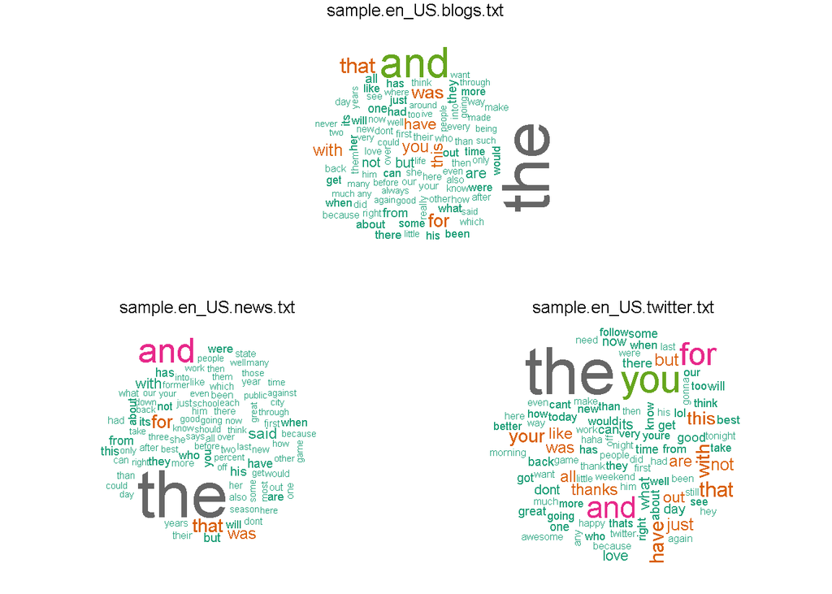

```r
display_wordcloud <-
  function(my_corpus,
           num = 100,
           n_gram = 1,
           palette = brewer.pal(8, "Dark2")) {
    frequency <- head(get_corpus_freq(my_corpus, n_gram), num)
    words <- names(frequency)
    my_title <- meta(my_corpus, "id")
    wordcloud(words, frequency, colors = palette)
    text(x = 0.5, y = 1, my_title)
  }

layout(matrix(c(1, 1, 2, 3), 2, 2, byrow = TRUE))
display_wordcloud(crps[1])  # blogs
display_wordcloud(crps[2])  # news
display_wordcloud(crps[3])  # twitter
```

#### 6.2 Plot frequencies by word.

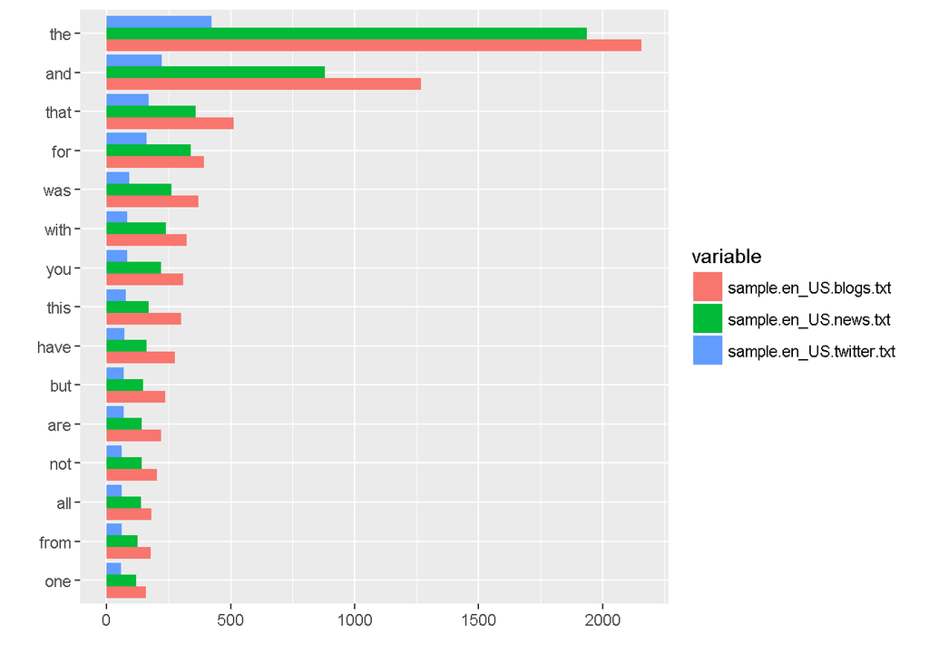

```r
freq_df <- data.frame(head(get_corpus_freq(crps[1]), 15),
                      head(get_corpus_freq(crps[2]), 15),
                      head(get_corpus_freq(crps[3]), 15))
names(freq_df) <- list.files(sample_dir(LANGUAGE), pattern = "*.txt")
freq_df$names <- rownames(freq_df)
freq_df <- melt(freq_df, id.vars = 4)

ggplot(freq_df, aes(reorder(names, value), value)) +
  geom_bar(aes(fill = variable), position = "dodge", stat = "identity") +
  coord_flip() +
  xlab("") +
  ylab("")
```

# 7. FULL SAMPLED CORPUS WORDS n-grams FREQUENCIES

An *n-gram* is a contiguous sequence of n items from a given sequence of text or speech. The corpus used are a sample from the files: *blogs, news and twitter* to plot the words *n-grams*, with n from 1 to 4.

```r
ggplot_ngram <- function(my_corpus, n = 1, num = 15){
  df <- data.frame(head(get_corpus_freq(my_corpus, n_gram = n), num))
  names(df) <- "value"
  df$names <- rownames(df)
  my_color <- brewer.pal(8, "Dark2")[n]
  p <- ggplot(df, aes(reorder(names, value), value)) +
    geom_bar(stat = "identity", fill = my_color) +
    coord_flip() +
    xlab("") +
    ylab("") +
    theme_minimal()
  return(p)
}
```

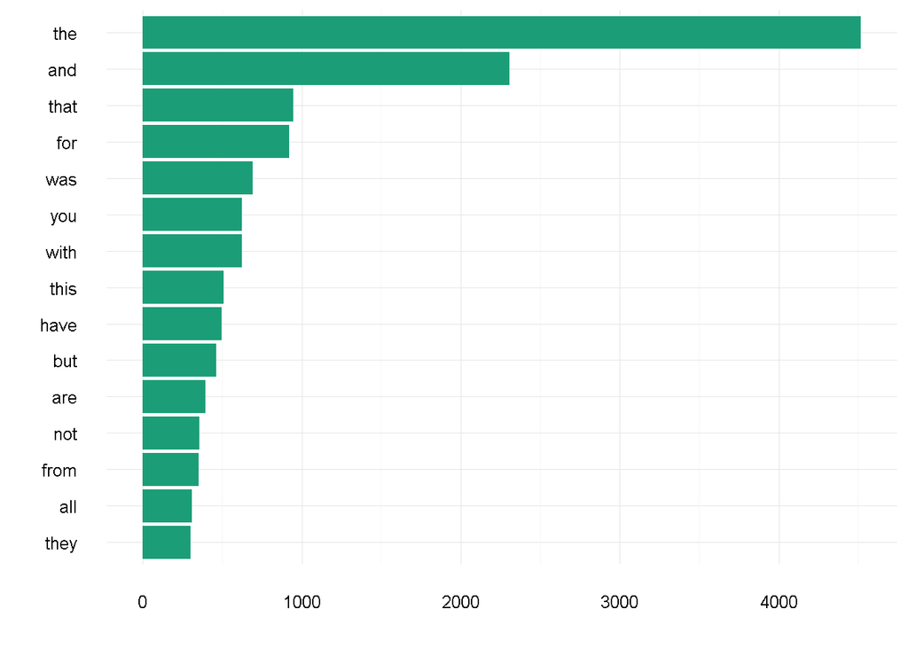

```r
ggplot_ngram(crps, n = 1)
```

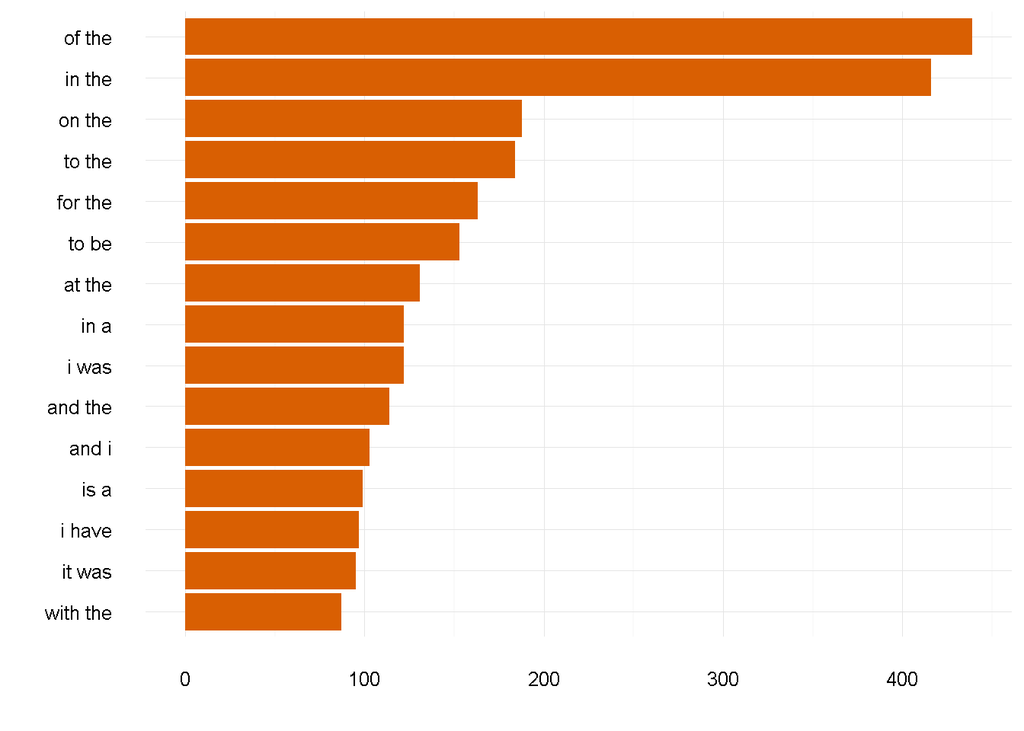

```r
ggplot_ngram(crps, n = 2)
```

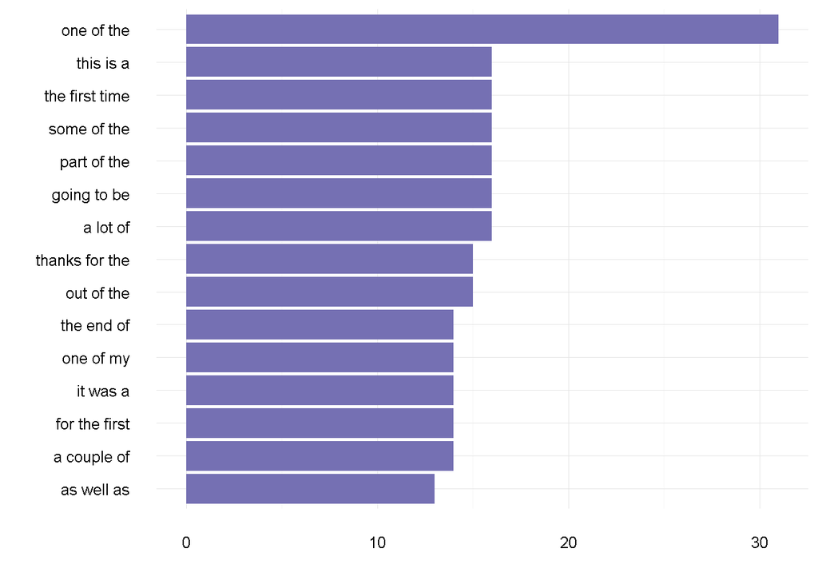

```r
ggplot_ngram(crps, n = 3)
```

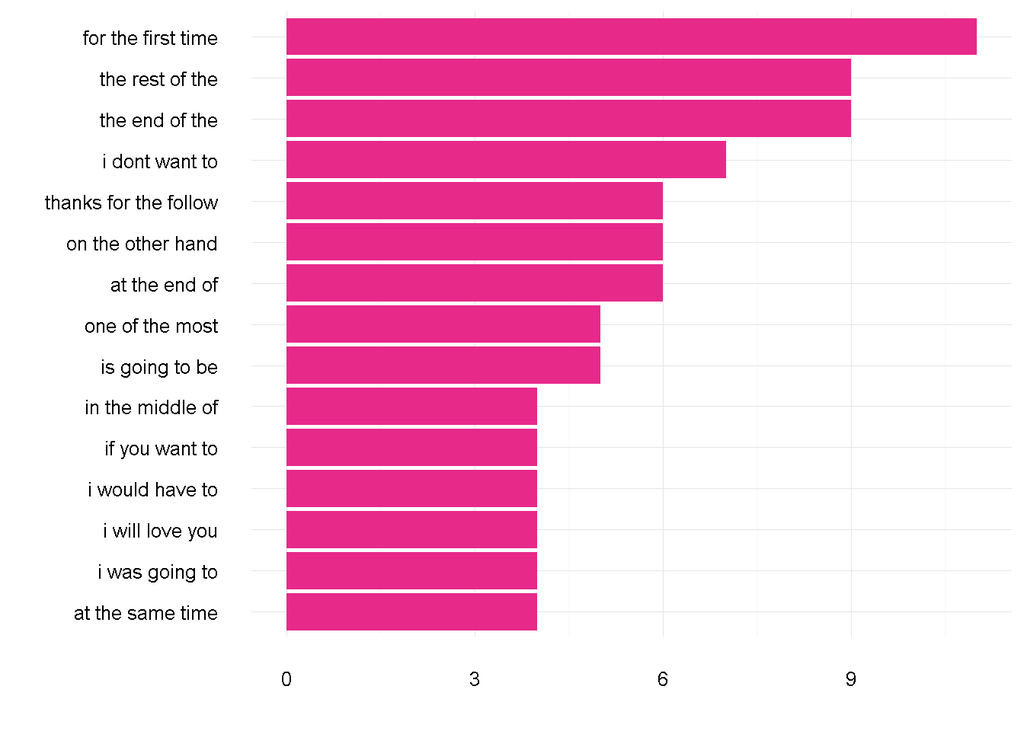

```r
ggplot_ngram(crps, n = 4)
```

# 8. UNI-GRAM COVERAGE:

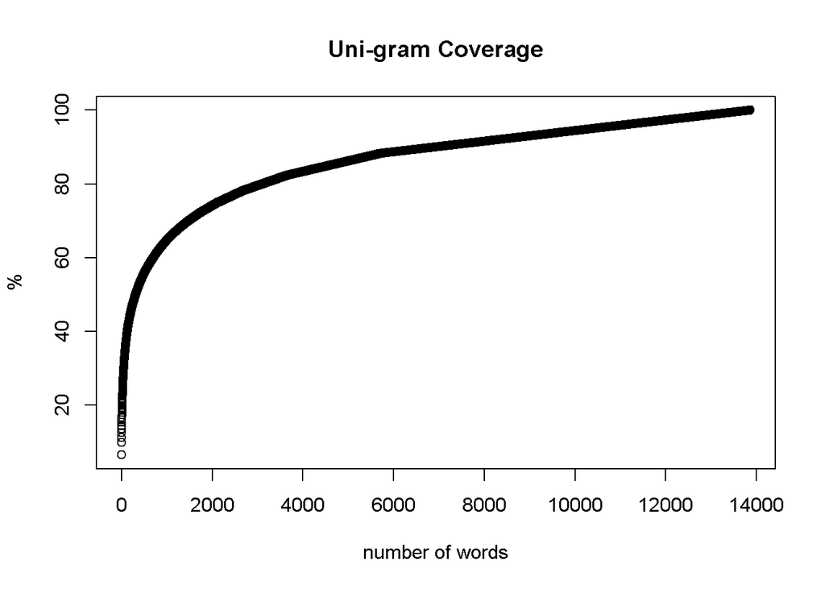

```r
n_gram1 <- data.frame(get_corpus_freq(crps, n_gram = 1))
names(n_gram1) <- "number"
n_gram1$number <- as.integer(n_gram1$number)
n_gram1$word <- rownames(n_gram1)

n_gram1 <- mutate(n_gram1, cumsum=cumsum(number))
n_gram1$cumsum <- 100 * n_gram1$cumsum / sum(n_gram1$number)

plot(n_gram1$cumsum, main = "Uni-gram Coverage",
     xlab = "number of words" ,
     ylab = "%"
     )
```

# 9. EVALUATING WORDS THAT COME FROM FOREIGN LANGUAGES.

This is a test of `texcat` package to test languages, but unfortunately the results are poor. So other methods must be used, for instance filtering for special characters or dictionary serching, packages `wordnet` or `qdapDictionaries`

```r
tex_lang <- data.frame(head(names(get_corpus_freq(crps)), 10))
names(tex_lang) <- c("word")
tex_lang$language <- textcat(tex_lang$word)

tex_lang
```

```
##    word   language
## 1   the    english
## 2   and    english
## 3  that    english
## 4   for     danish
## 5   was      scots
## 6   you    swahili
## 7  with      welsh
## 8  this    english
## 9  have  norwegian
## 10  but indonesian
```

## Links:

- Github: NLP-Coursera-Swiftkey
- Wikipedia: [n-gram](https://en.wikipedia.org/wiki/N-gram)
- Stackoverflow: [Side-by-side plots with ggplot2](http://stackoverflow.com/questions/1249548/side-by-side-plots-with-ggplot2)
- [Introduction to the tm Package, Text Mining in R, Ingo Feinerer, July 3, 2015](https://cran.r-project.org/web/packages/tm/vignettes/tm.pdf)
- Stackoverflow: [tm package for word count](http://stackoverflow.com/questions/26510298/rs-tm-package-for-word-count)
- Stackoverflow: [Easy way of determining number if lines records](http://www.r-bloggers.com/easy-way-of-determining-number-of-linesrecords-in-a-given-large-file-using-r/)
- Stackoverflow: [Count the number of words in a string in r](http://stackoverflow.com/questions/8920145/count-the-number-of-words-in-a-string-in-r)
- DeltaDna: [Text mining in r](https://deltadna.com/blog/text-mining-in-r-for-term-frequency/)
- Stackoverflow: [Removing on english text from corpus in r](http://stackoverflow.com/questions/18153504/removing-non-english-text-from-corpus-in-r-using-tm)
- Stackoverflow: [Filtering non english words from a corpus with textcat](http://stackoverflow.com/questions/18447920/filtering-out-non-english-words-from-a-corpus-using-textcat)
- [R: add title to wordcloud graphics / png](http://stackoverflow.com/questions/15224913/r-add-title-to-wordcloud-graphics-png)